# individual1

Tim Potter

February 19, 2019

## R Markdown

```r
data(happy, package="productplots")
head(happy)
```

```
##   id         happy year age    sex       marital         degree
## 1  1 not too happy 1972  23 female never married       bachelor
## 2  2 not too happy 1972  70   male       married lt high school
## 3  3  pretty happy 1972  48 female       married    high school
## 4  4 not too happy 1972  27 female       married       bachelor
## 5  5  pretty happy 1972  61 female       married    high school
## 6  6  pretty happy 1972  26   male never married    high school
##         finrela    health wtssall
## 1       average      good  0.4446
## 2 above average      fair  0.8893
## 3       average excellent  0.8893
## 4       average      good  0.8893
## 5 above average      good  0.8893
## 6 above average      good  0.4446
```

```r
HAPPY <- readRDS("HAPPY.rds")
head(HAPPY)
```

```
##           HAPPY YEAR AGE    SEX       MARITAL         DEGREE       FINRELA
## 1 NOT TOO HAPPY 1972  23 FEMALE NEVER MARRIED       BACHELOR       AVERAGE
## 2 NOT TOO HAPPY 1972  70   MALE       MARRIED LT HIGH SCHOOL ABOVE AVERAGE
## 3  PRETTY HAPPY 1972  48 FEMALE       MARRIED    HIGH SCHOOL       AVERAGE
## 4 NOT TOO HAPPY 1972  27 FEMALE       MARRIED       BACHELOR       AVERAGE
## 5  PRETTY HAPPY 1972  61 FEMALE       MARRIED    HIGH SCHOOL ABOVE AVERAGE
## 6  PRETTY HAPPY 1972  26   MALE NEVER MARRIED    HIGH SCHOOL ABOVE AVERAGE
##      HEALTH WTSSALL          PARTYID POLVIEWS
## 1      GOOD  0.4446     IND,NEAR DEM      IAP
## 2      FAIR  0.8893 NOT STR DEMOCRAT      IAP
## 3 EXCELLENT  0.8893      INDEPENDENT      IAP
## 4      GOOD  0.8893 NOT STR DEMOCRAT      IAP
## 5      GOOD  0.8893  STRONG DEMOCRAT      IAP
## 6      GOOD  0.4446     IND,NEAR DEM      IAP
```

```r
library(naniar)
library(ggplot2)
```

# Part 1

```r
HAPPY <- replace_with_na_all(data = HAPPY, condition = ~.x %in% c("IAP", "DK", "NA"))
HAPPY
```

```
## # A tibble: 62,466 x 11
##    HAPPY  YEAR AGE   SEX   MARITAL DEGREE FINRELA HEALTH WTSSALL PARTYID
##    <chr> <int> <chr> <chr> <chr>   <chr>  <chr>   <chr>    <dbl> <chr>
##  1 NOT ~  1972 23    FEMA~ NEVER ~ BACHE~ AVERAGE GOOD     0.445 IND,NE~
##  2 NOT ~  1972 70    MALE  MARRIED LT HI~ ABOVE ~ FAIR     0.889 NOT ST~
##  3 PRET~  1972 48    FEMA~ MARRIED HIGH ~ AVERAGE EXCEL~   0.889 INDEPE~
##  4 NOT ~  1972 27    FEMA~ MARRIED BACHE~ AVERAGE GOOD     0.889 NOT ST~
##  5 PRET~  1972 61    FEMA~ MARRIED HIGH ~ ABOVE ~ GOOD     0.889 STRONG~
##  6 PRET~  1972 26    MALE  NEVER ~ HIGH ~ ABOVE ~ GOOD     0.445 IND,NE~
##  7 NOT ~  1972 28    MALE  DIVORC~ HIGH ~ ABOVE ~ EXCEL~   0.445 IND,NE~
##  8 NOT ~  1972 27    MALE  NEVER ~ BACHE~ AVERAGE GOOD     0.445 IND,NE~
##  9 PRET~  1972 21    FEMA~ NEVER ~ HIGH ~ AVERAGE EXCEL~   0.445 STRONG~
## 10 PRET~  1972 30    FEMA~ MARRIED HIGH ~ BELOW ~ FAIR     0.889 STRONG~
## # ... with 62,456 more rows, and 1 more variable: POLVIEWS <chr>
```

```r
str(HAPPY$HAPPY)
```

```
##  chr [1:62466] "NOT TOO HAPPY" "NOT TOO HAPPY" "PRETTY HAPPY" ...
```

```r
str(HAPPY$AGE)
```

```
##  chr [1:62466] "23" "70" "48" "27" "61" "26" "28" "27" "21" "30" "30" ...
```

```r
HAPPY$AGE[HAPPY$AGE == "89 OR OLDER"] <- 89
HAPPY$AGE <- as.numeric(as.character(HAPPY$AGE))
str(HAPPY$AGE)
```

```
##  num [1:62466] 23 70 48 27 61 26 28 27 21 30 ...
```

# Part 2

1. Looking at the distribution of the marital status of the respondents, the vast majority of those in the data set have been married at least once. Most people are still married, with a fair percentage of people having been divorced or separated. The distribution of the ages of the people surveyed show a sharp rise up until around 30, followed by a steady decline down to 89.

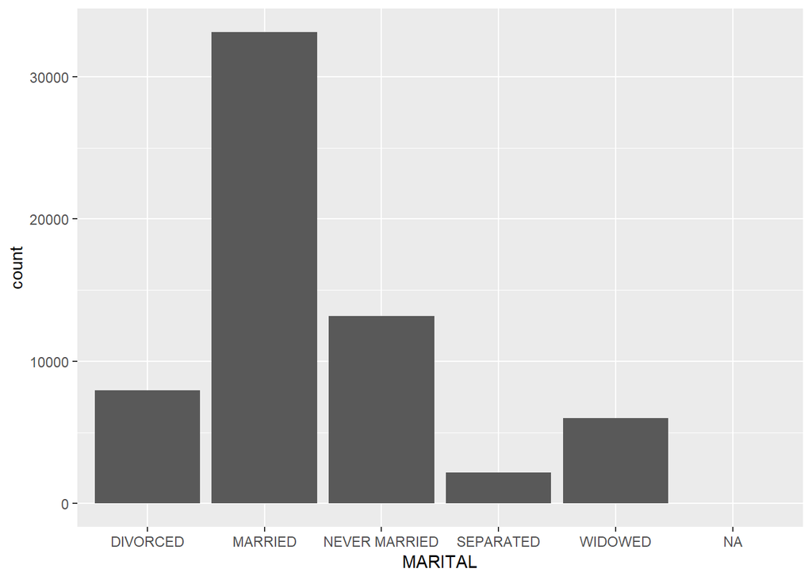

```r
ggplot(data = HAPPY, aes(x = MARITAL)) + geom_bar()
```

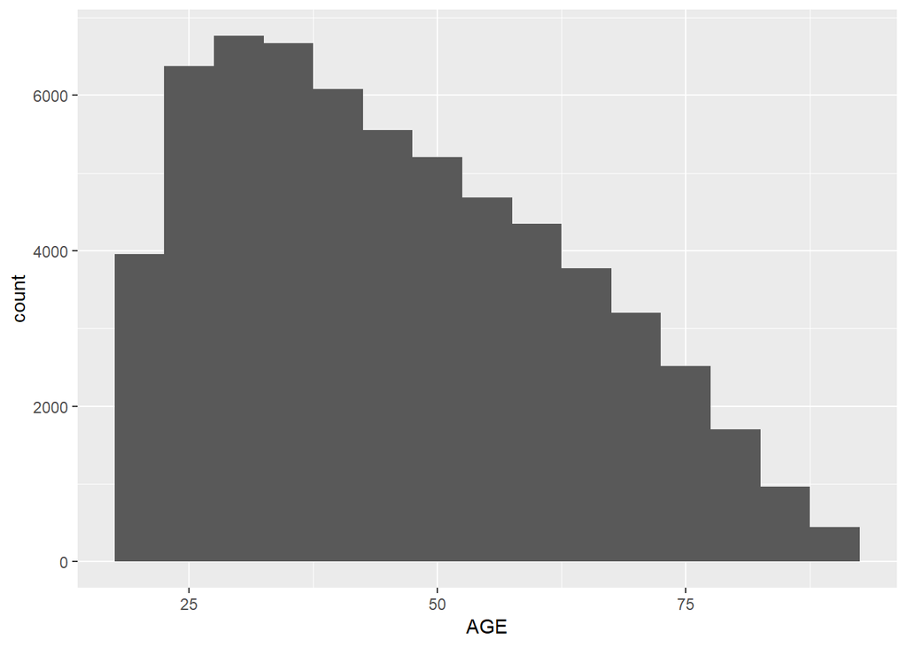

```r
ggplot(data =HAPPY, aes(x = AGE)) + geom_histogram(binwidth = 5)
```

2.Happiness based on several other variables.

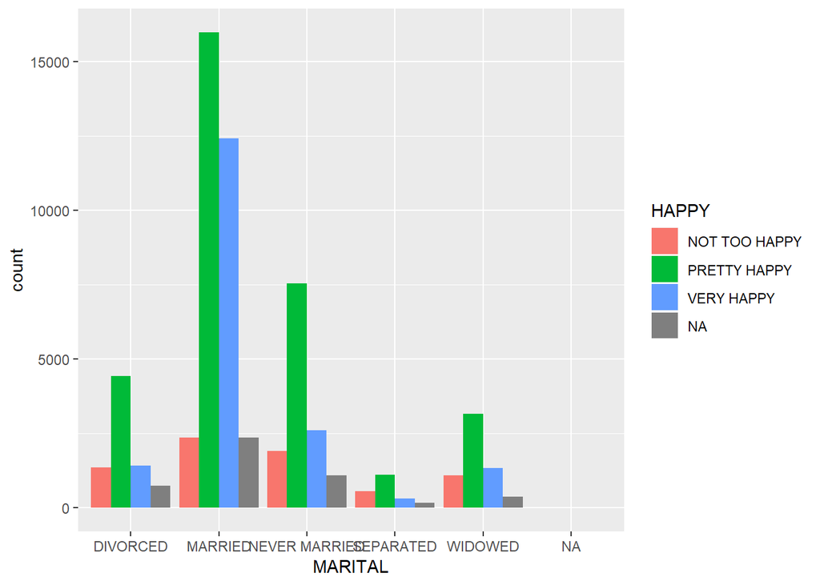

```r
ggplot(data = HAPPY, aes(x = MARITAL, fill = HAPPY)) + geom_bar(position = position_dodge())
```

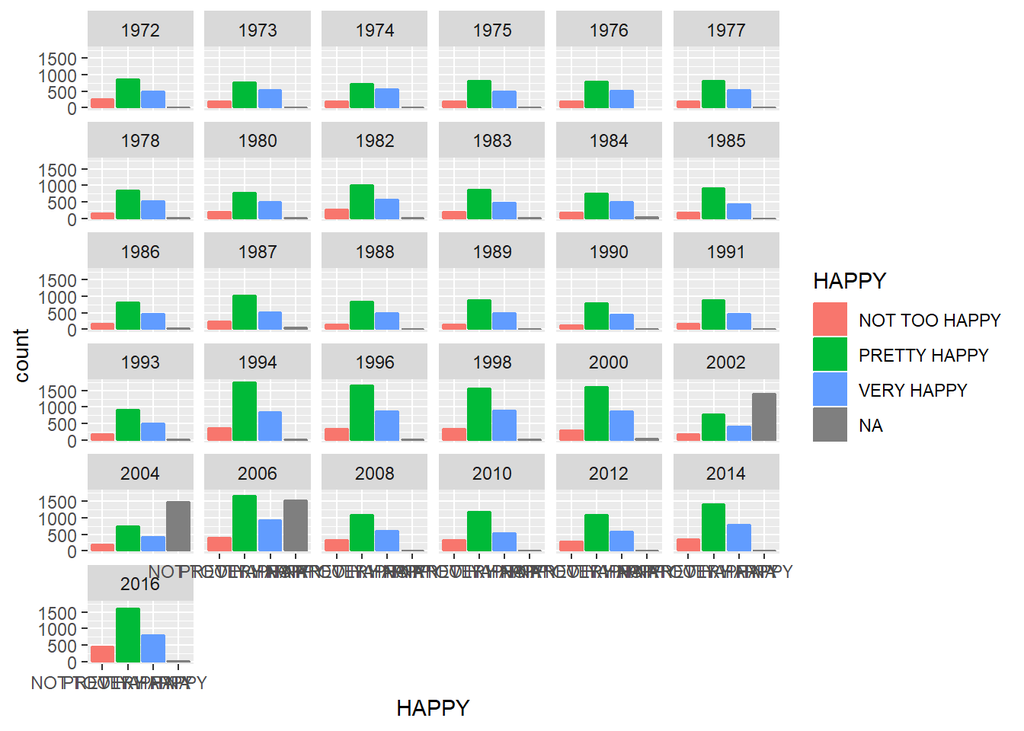

```r
ggplot(data= HAPPY, aes(x = HAPPY, color = HAPPY, fill = HAPPY)) + geom_bar() + facet_wrap(~YEAR)
```

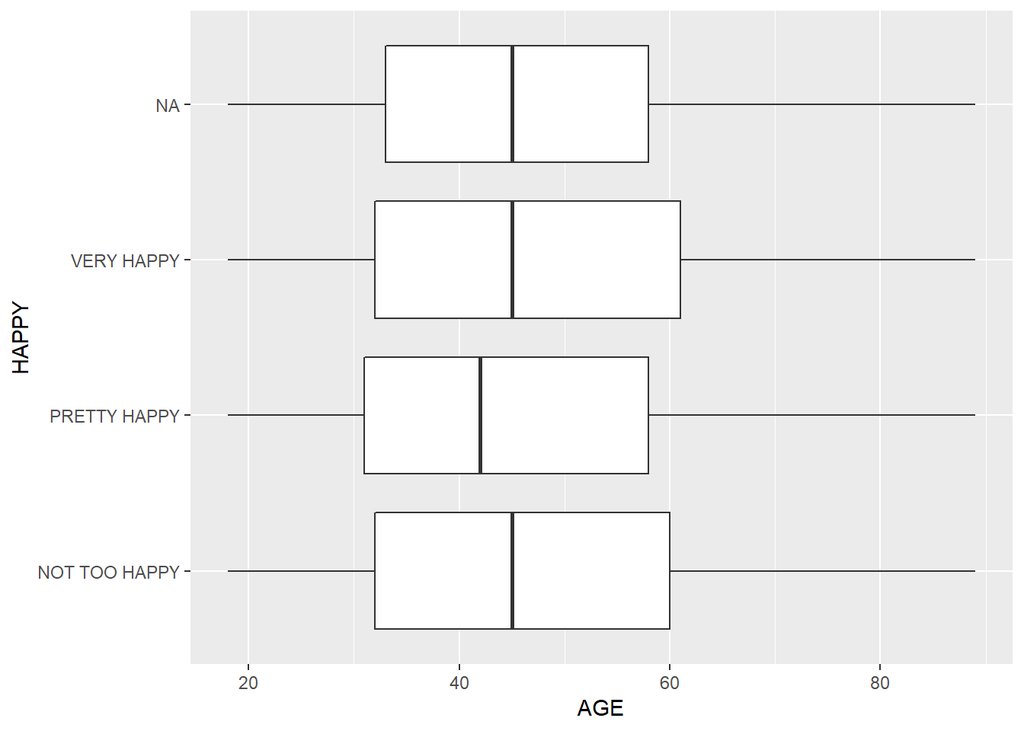

```r
ggplot(data= HAPPY, aes(x = HAPPY, y = AGE)) + geom_boxplot() + coord_flip()
```

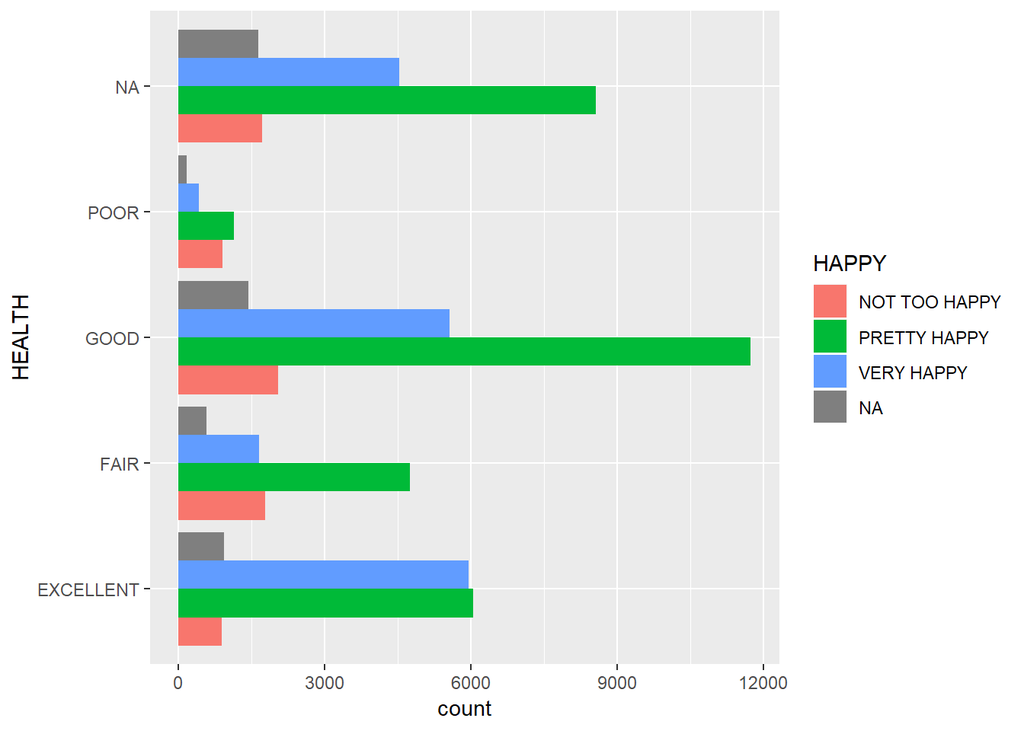

```r
ggplot(data = HAPPY, aes(x = HEALTH, fill = HAPPY)) + geom_bar(position = position_dodge()) + coord_flip()
```

3. Takeaway Looking through the graphs, happiness is obviously affected by other variables, and yet it seems people overall are pretty happy. People who are married have a much greater chance of being very happy, and yet everyone else still has a pretty happy majority. Overs the years, the population has always been either pretty happy or very happy, opposed to not very happy. Age doesn’t seem to have an impact on overall happiness. Health does seem to have more of an impact. People with poor health are not happy more than others, while people with excellent health are overall very happy or pretty happy. This goes to show that people will *at least* say they’re pretty happy over anything else.